# Data Science Capstone-Final Project

## Coverage analysis

Here we are trying to understand how much of sample data is representative of overall training set

```r
getThreshold<-function(data,percentage){
total<-sum(data[,2])
coverage<-percentage*total/100
current_value<-0
for (i in 1:nrow(data))
{
  if (current_value > coverage) {
    return(i)
  }
  current_value<-current_value+data[i,2]
}
return(nrow(data))
}
getThreshold(d1,50)
```

```
## [1] 452
```

```r
getThreshold(d1,90)
```

```
## [1] 3002
```

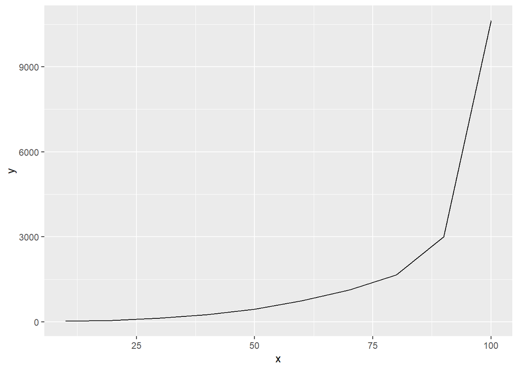

```r
x <- seq(10, 100, by = 10)
y<-0
for (i in 1:10) {
y[i]<-getThreshold(d1,x[i])
}
qplot(x,y,geom=c("line"))
```

# N-Gram Language Model

We will comute the probablity of next word based on previous one. probablity(word1,word2)=probablity(word1)*probablity(word2!word1) probability(word1,word2,word3)=probablity(word1)*probablity(word2!word1)*probablity(word3,word2,word1) General formula P(x1, x2, …, xn) = P(x1)P(x2|x1)…P(xn|x1,…xn-1)

$$\begin{eqnarray}
P(w_{a}) & = & \frac{C(w_{a})}{N}\\
P(w_{a}|w_{b}) & = & \frac{C(w_{a},w_{b})}{\sum_{w_{b}}C(w_{a},w_{b})}\\
P(w_{a}|w_{b}) & \sim & \frac{C(w_{a},w_{b})}{C(w_{b})}\\
\end{eqnarray}$$
where N is the total number of words in the training set and c(·) denotes count of the word or word sequence in the training data The probability will be undefined for words which was never seen in corpus. We apply laplace smoothing as following for correcting probablity for unseen data
$$\begin{eqnarray}
P(w_{a}) & = & \frac{C(w_{a})+\delta}{N+V*\delta}
\end{eqnarray}$$

```r
# helper function

library(tidyr)
library(data.table)

#Returns probability of unigram
get_unigram_words<-function(sentence){
                data<-data_frame(word=unlist(sentence))
                data1 <- data.table(data) %>%
                unnest_tokens(word1,word, token = "ngrams", n = 1)

                data1<-copy(data1)
                data1<-data1[,.N,word1]
                #V<-nrow(data1)
                total_count<-sum(data1$N)

                data1<-data1 %>% mutate(prob=(log((N+delta)-log(V*delta+total_count))))  %>%      select(-N)

                #data1$prob<-mapply(pword1,data1$word1,data1)
                #size<-nrow(data1)
                #data1<-aggregate(data1[, 2], list(data1$word1), mean)
                #V<-nrow(data1)
                #names(data1)<-c("word1","prob")
                data1<-unique(data1)
                setorder(data1,-prob)
              return(list(total_count,data1))
}

#return list of matrix with n rows and 2 column
#Returns probability of unigram
get_bigram_words<-function(sentence){
                data<-data_frame(word=unlist(sentence))
                data1 <- data.table(data) %>%
                unnest_tokens(bigram,word, token = "ngrams", n = 2) %>%
                separate(bigram, c("word1", "word2"), sep = " ")
                #names(data1)<-c("word1","word2","word1_count","word2_count")
                data1<-copy(data1)
                data1<-data1[,  word1_count:= (.N), by = .(word1)]
                data1<-data1[, word2_count := (.N), by = .(word1,word2)]

                #data1<-data1[, `:=` (word1_count = .N), by = .(word1)]
                #data1<-data1[, `:=` (word2_count = .N), by = .(word1,word2)]

               # V<-nrow(data1)
                total_count<-sum(data1$word2_count)

                data1<-data1 %>% mutate(prob=(log((word2_count+delta)-log(V*delta+word1_count))) ) %>%      select(-c("word1_count","word2_count"))
                data1<-unique(data1)
               setorder(data1,-prob)
              return(list(total_count,data1))
}
#return list of matrix with n rows and 3 column
get_trigram_words<-function(sentence){
               data<-data_frame(word=unlist(sentence))
                data1 <- data.table(data) %>%
                unnest_tokens(trigram,word, token = "ngrams", n = 3) %>%
                separate(trigram, c("word1", "word2","word3"), sep = " ")

                data1<-copy(data1)
                data1<-data1[, `:=` (word2_count = .N), by = .(word1,word2)]
                data1<-data1[, `:=` (word3_count = .N), by = .(word1,word2,word3)]

                #V<-nrow(data1)
                total_count<-sum(data1$word3_count)

                data1<-data1 %>% mutate(prob=(log((word3_count+delta)-log(V*delta+word2_count))))  %>%      select(-c("word2_count","word3_count"))
                data1<-unique(data1)
               setorder(data1,-prob)
              return(list(total_count,data1))

}
#return list of matrix with n rows and 4 column
get_quadgram_words<-function(sentence){
               data<-data_frame(word=unlist(sentence))
                data1 <- data.table(data) %>%
                unnest_tokens(quadgram,word, token = "ngrams", n = 4) %>%
                separate(quadgram, c("word1", "word2","word3","word4"), sep = " ")

            data1<-copy(data1)
           data1<-data1[, `:=` (word3_count = .N), by = .(word1,word2,word3)]
           data1<-data1[, `:=` (word4_count = .N), by = .(word1,word2,word3,word4)]

                #V<-nrow(data1)
                total_count<-sum(data1$word4_count)

                data1<-data1 %>% mutate(prob=(log((word4_count+delta)-log(V*delta+word3_count))))  %>%      select(-c("word3_count","word4_count"))
                data1<-unique(data1)
               setorder(data1,-prob)
              return(list(total_count,data1))
}


update_model_unigram<-function(newsample) {

     first_time<-FALSE

  if(!file.exists(destfile1))
    {
     # print("i am here")
      print(destfile1)
      q1<-get_unigram_words(newsample)
      saveRDS(q1,file=destfile1)
      first_time<-TRUE
  }
     else p1<-readRDS(file=destfile1)



 if (!first_time)
 {
  q1<-get_unigram_words(newsample)


 q1[[2]]$size <- rep(q1[[1]],nrow(q1[[2]]))
 p1[[2]]$size <- rep(p1[[1]],nrow(p1[[2]]))
 totalsize<-q1[[1]]+p1[[1]]

  c1<-bind_rows(q1[[2]], p1[[2]]) %>%
    group_by(word1) %>%
    summarise_all(funs(weighted.mean(.,size)))  %>% select(-size)
  setorder(c1,-prob)
  c1<-list(totalsize,c1)
 # print(c1)

  saveRDS(c1,file=destfile1)

 }

}

update_model_bigram<-function(newsample) {

     first_time<-FALSE

  if(!file.exists(destfile2))
     {
      q2<-get_bigram_words(newsample)
      q2<-q2[[2]] %>% top_n(V*delta)
      q2<-list(nrow(q2),q2)
      saveRDS(q2,file=destfile2)
      first_time<-TRUE
  }
     else {
       p2<-readRDS(file=destfile2)
      p2<-p2[[2]] %>% top_n(V*delta)
     }

 if (!first_time)
 {

  q2<-get_bigram_words(newsample)
  q2<-q2[[2]] %>% top_n(V*delta)

   c2<-bind_rows(q2, p2)
  totalsize<-nrow(c2)


   data1<-copy(data.table(c2)%>% select(-c("prob")))

                data1<-data1[,  word1_count:= (.N), by = .(word1)]
                data1<-data1[, word2_count := (.N), by = .(word1,word2)]
                total_count<-sum(data1$word2_count)
                data1<-data1 %>% mutate(prob=(log((word2_count+delta)-log(V*delta+word1_count))))  %>%      select(-c("word1_count","word2_count"))
                data1<-unique(data1)

               setorder(data1,-prob)
               c2<-data1

  c2<-list(totalsize,c2)

  saveRDS(c2,file=destfile2)


 }

}

update_model_trigram<-function(newsample) {

     first_time<-FALSE
  if(!file.exists(destfile3))
     {
      q2<-get_trigram_words(newsample)
      q2<-q2[[2]] %>% top_n(V*delta)
      q2<-list(nrow(q2),q2)
      saveRDS(q2,file=destfile3)
      first_time<-TRUE
  }
     else {
       p2<-readRDS(file=destfile3)
      p2<-p2[[2]] %>% top_n(V*delta)
     }

 if (!first_time)
 {
  q2<-get_trigram_words(newsample)
  q2<-q2[[2]] %>% top_n(V*delta)
  c2<-bind_rows(q2, p2)
  totalsize<-nrow(c2)
  data1<-copy(data.table(c2)%>% select(-c("prob")))
  data1<-data1[, `:=` (word2_count = .N), by = .(word1,word2)]
                data1<-data1[, `:=` (word3_count = .N), by = .(word1,word2,word3)]

                #V<-nrow(data1)
                total_count<-sum(data1$word3_count)

                data1<-data1 %>% mutate(prob=(log((word3_count+delta)-log(V*delta+word2_count))) ) %>%      select(-c("word2_count","word3_count"))
                data1<-unique(data1)
               setorder(data1,-prob)
               c2<-data1
  c2<-list(totalsize,c2)
  saveRDS(c2,file=destfile3)
 }
}

update_model_quadgram<-function(newsample) {

     first_time<-FALSE
  if(!file.exists(destfile4))
     {
      q2<-get_quadgram_words(newsample)
      q2<-q2[[2]] %>% top_n(V*delta)
      q2<-list(nrow(q2),q2)
      saveRDS(q2,file=destfile4)
      first_time<-TRUE
  }
     else {
       p2<-readRDS(file=destfile4)
      p2<-p2[[2]] %>% top_n(V*delta)
     }

 if (!first_time)
 {
  q2<-get_quadgram_words(newsample)
  q2<-q2[[2]] %>% top_n(V*delta)
  c2<-bind_rows(q2, p2)
  totalsize<-nrow(c2)
  data1<-copy(data.table(c2)%>% select(-c("prob")))
  data1<-data1[, `:=` (word2_count = .N), by = .(word1,word2)]
                data1<-data1[, `:=` (word3_count = .N), by = .(word1,word2,word3)]

                #V<-nrow(data1)
                total_count<-sum(data1$word3_count)

                data1<-data1 %>% mutate(prob=(log((word3_count+delta)-log(V*delta+word2_count))))  %>%      select(-c("word2_count","word3_count"))
                data1<-unique(data1)
               setorder(data1,-prob)
               c2<-data1
  c2<-list(totalsize,c2)
  saveRDS(c2,file=destfile4)
 }
}
```